# ProyectoFinal

### **PROYECTO FINAL** *Ciencia de datos en Python* .

##### *Proyecto elaborado por:*

- Darwin Rojas 23008435
- Marvin Santizo 06382006

```python
import pandas as pd
import numpy as np
import configparser
import matplotlib.pyplot as plt
import seaborn as sns
```

### **Conexión a BD MySql**

```python
config=configparser.ConfigParser()
config.read('configDB.cfg')
```

```
['configDB.cfg']
```

```python
mysql_driver = f"""mysql+pymysql://{config.get('flights', 'DB_USERNAME')}:{config.get('flights', 'DB_PASSWORD')}@{config.get('flights', 'DB_HOST')}:{config.get('flights', 'DB_PORT')}/{config.get('flights', 'DB_NAME')}"""

mysql_driver
```

```
'mysql+pymysql://admin_flights:proyectofinalpython2024!@db-project-flights.cro426i8eulo.us-east-2.rds.amazonaws.com:3306/flights_db'
```

### **Lectura y carga de tablas NYCFLIGHTS**

#### ***FLIGHTS***

```python
flights_data=pd.read_csv('./Proyecto-Final-CDP-flights/data/flights.csv')
flights_data.head()
```

|  | year | month | day | dep_time | sched_dep_time | dep_delay | arr_time | sched_arr_time | arr_delay | carrier | flight | tailnum | origin | dest | air_time | distance | hour | minute | time_hour |
| --- | --- | --- | --- | --- | --- | --- | --- | --- | --- | --- | --- | --- | --- | --- | --- | --- | --- | --- | --- |
| 0 | 2013 | 1 | 1 | 517.0 | 515 | 2.0 | 830.0 | 819 | 11.0 | UA | 1545 | N14228 | EWR | IAH | 227.0 | 1400 | 5 | 15 | 2013-01-01 05:00:00 |
| 1 | 2013 | 1 | 1 | 533.0 | 529 | 4.0 | 850.0 | 830 | 20.0 | UA | 1714 | N24211 | LGA | IAH | 227.0 | 1416 | 5 | 29 | 2013-01-01 05:00:00 |
| 2 | 2013 | 1 | 1 | 542.0 | 540 | 2.0 | 923.0 | 850 | 33.0 | AA | 1141 | N619AA | JFK | MIA | 160.0 | 1089 | 5 | 40 | 2013-01-01 05:00:00 |
| 3 | 2013 | 1 | 1 | 544.0 | 545 | -1.0 | 1004.0 | 1022 | -18.0 | B6 | 725 | N804JB | JFK | BQN | 183.0 | 1576 | 5 | 45 | 2013-01-01 05:00:00 |
| 4 | 2013 | 1 | 1 | 554.0 | 600 | -6.0 | 812.0 | 837 | -25.0 | DL | 461 | N668DN | LGA | ATL | 116.0 | 762 | 6 | 0 | 2013-01-01 06:00:00 |

#### ***AIRLINES***

```python
airlines_data=pd.read_csv('./Proyecto-Final-CDP-flights/data/airlines.csv')
airlines_data.head()
```

|  | carrier | name |
| --- | --- | --- |
| 0 | 9E | Endeavor Air Inc. |
| 1 | AA | American Airlines Inc. |
| 2 | AS | Alaska Airlines Inc. |
| 3 | B6 | JetBlue Airways |
| 4 | DL | Delta Air Lines Inc. |

#### ***PLANES***

```python
planes_data=pd.read_csv('./Proyecto-Final-CDP-flights/data/planes.csv')
planes_data.head()

df_joined = flights_data[~flights_data['tailnum'].isin(planes_data['tailnum'])]
df_joined= df_joined.drop_duplicates(subset=['tailnum'])
df_joined=df_joined.filter(like='tailnum')
df_joined



planes_data_ok= pd.DataFrame(pd.concat([planes_data, df_joined], axis=0))
planes_data_ok
```

|  | tailnum | year | type | manufacturer | model | engines | seats | speed | engine |
| --- | --- | --- | --- | --- | --- | --- | --- | --- | --- |
| 0 | N10156 | 2004.0 | Fixed wing multi engine | EMBRAER | EMB-145XR | 2.0 | 55.0 | NaN | Turbo-fan |
| 1 | N102UW | 1998.0 | Fixed wing multi engine | AIRBUS INDUSTRIE | A320-214 | 2.0 | 182.0 | NaN | Turbo-fan |
| 2 | N103US | 1999.0 | Fixed wing multi engine | AIRBUS INDUSTRIE | A320-214 | 2.0 | 182.0 | NaN | Turbo-fan |
| 3 | N104UW | 1999.0 | Fixed wing multi engine | AIRBUS INDUSTRIE | A320-214 | 2.0 | 182.0 | NaN | Turbo-fan |
| 4 | N10575 | 2002.0 | Fixed wing multi engine | EMBRAER | EMB-145LR | 2.0 | 55.0 | NaN | Turbo-fan |
| ... | ... | ... | ... | ... | ... | ... | ... | ... | ... |
| 266825 | N823MQ | NaN | NaN | NaN | NaN | NaN | NaN | NaN | NaN |
| 290770 | N5FCAA | NaN | NaN | NaN | NaN | NaN | NaN | NaN | NaN |
| 294243 | N5ERAA | NaN | NaN | NaN | NaN | NaN | NaN | NaN | NaN |
| 302529 | N654MQ | NaN | NaN | NaN | NaN | NaN | NaN | NaN | NaN |
| 324307 | N647MQ | NaN | NaN | NaN | NaN | NaN | NaN | NaN | NaN |

4044 rows × 9 columns

#### ***WEATHER***

```python
weather_data=pd.read_csv('./Proyecto-Final-CDP-flights/data/weather.csv')
weather_data.head()


weather_data_dup=weather_data.drop_duplicates(subset=['origin', 'year','month','day','hour'],keep='first')


weather_data_dup=weather_data_dup[['origin', 'year','month','day','hour']]
flights_data_key=flights_data[['origin', 'year','month','day','hour']]
flights_data

concat_wf= pd.DataFrame(pd.concat([weather_data_dup, flights_data_key], axis=0))
concat_wf=concat_wf.drop_duplicates(subset=['origin', 'year','month','day','hour'],keep='first')
concat_wf

weather_final= pd.DataFrame(pd.concat([weather_data, concat_wf], axis=0))
weather_final=concat_final.drop_duplicates(subset=['origin', 'year','month','day','hour'],keep='first')
weather_final
```

|  | origin | year | month | day | hour | temp | dewp | humid | wind_dir | wind_speed | wind_gust | precip | pressure | visib | time_hour |
| --- | --- | --- | --- | --- | --- | --- | --- | --- | --- | --- | --- | --- | --- | --- | --- |
| 0 | EWR | 2013 | 1 | 1 | 1 | 39.02 | 26.06 | 59.37 | 270.0 | 10.35702 | NaN | 0.0 | 1012.0 | 10.0 | 2013-01-01T06:00:00Z |
| 1 | EWR | 2013 | 1 | 1 | 2 | 39.02 | 26.96 | 61.63 | 250.0 | 8.05546 | NaN | 0.0 | 1012.3 | 10.0 | 2013-01-01T07:00:00Z |
| 2 | EWR | 2013 | 1 | 1 | 3 | 39.02 | 28.04 | 64.43 | 240.0 | 11.50780 | NaN | 0.0 | 1012.5 | 10.0 | 2013-01-01T08:00:00Z |
| 3 | EWR | 2013 | 1 | 1 | 4 | 39.92 | 28.04 | 62.21 | 250.0 | 12.65858 | NaN | 0.0 | 1012.2 | 10.0 | 2013-01-01T09:00:00Z |
| 4 | EWR | 2013 | 1 | 1 | 5 | 39.02 | 28.04 | 64.43 | 260.0 | 12.65858 | NaN | 0.0 | 1011.9 | 10.0 | 2013-01-01T10:00:00Z |
| ... | ... | ... | ... | ... | ... | ... | ... | ... | ... | ... | ... | ... | ... | ... | ... |
| 300698 | EWR | 2013 | 8 | 22 | 18 | NaN | NaN | NaN | NaN | NaN | NaN | NaN | NaN | NaN | NaN |
| 300705 | JFK | 2013 | 8 | 22 | 18 | NaN | NaN | NaN | NaN | NaN | NaN | NaN | NaN | NaN | NaN |
| 300813 | JFK | 2013 | 8 | 22 | 20 | NaN | NaN | NaN | NaN | NaN | NaN | NaN | NaN | NaN | NaN |
| 300830 | EWR | 2013 | 8 | 22 | 20 | NaN | NaN | NaN | NaN | NaN | NaN | NaN | NaN | NaN | NaN |
| 310417 | EWR | 2013 | 9 | 2 | 16 | NaN | NaN | NaN | NaN | NaN | NaN | NaN | NaN | NaN | NaN |

26220 rows × 15 columns

#### ***AIRPORT***

```python
airport_data=pd.read_csv('./Proyecto-Final-CDP-flights/data/airports.csv')
airport_data.head()
```

|  | faa | name | lat | lon | alt | tz | dst | tzone |
| --- | --- | --- | --- | --- | --- | --- | --- | --- |
| 0 | 04G | Lansdowne Airport | 41.130472 | -80.619583 | 1044 | -5 | A | America/New_York |
| 1 | 06A | Moton Field Municipal Airport | 32.460572 | -85.680028 | 264 | -6 | A | America/Chicago |
| 2 | 06C | Schaumburg Regional | 41.989341 | -88.101243 | 801 | -6 | A | America/Chicago |
| 3 | 06N | Randall Airport | 41.431912 | -74.391561 | 523 | -5 | A | America/New_York |
| 4 | 09J | Jekyll Island Airport | 31.074472 | -81.427778 | 11 | -5 | A | America/New_York |

# **Carga a tablas SQL**

```python
airlines_data.to_sql('airlines',mysql_driver,index=False,if_exists='append')
```

```
16
```

```python
airport_data.to_sql('airport',mysql_driver,index=False,if_exists='append')
```

```
1458
```

```python
planes_data_ok.to_sql('planes',mysql_driver,index=False,if_exists='append')
```

```
4044
```

```python
weather_final.to_sql('weather',mysql_driver,index=False,if_exists='append')
```

```
26220
```

```python
flights_data.to_sql('flights',mysql_driver,index=False,if_exists='append')
```

```
336776
```

# **10 Preguntas de negocio**

#### *1. ¿Cuál es el avión con mayor tiempo de aire?*

```python
sql_query = 'SELECT tailnum,air_time FROM flights;'
table_flights= pd.read_sql(sql_query, mysql_driver)
```

```python
table_air_time=table_flights.groupby(['tailnum']).count()
table_air_time.sort_values(by='air_time', ascending=False)[:1]
```

| tailnum | air_time |
| --- | --- |
| N725MQ | 544 |

#### 2. *¿Cuáles son las 3 aerolínea con mayor número de vuelos?*

```python
sql_query = 'SELECT tailnum,carrier FROM flights;'
table_flights2= pd.read_sql(sql_query, mysql_driver)

sql_query = 'SELECT carrier FROM airlines;'
table_airlines= pd.read_sql(sql_query, mysql_driver)
```

```python
table_merge1=table_flights2.merge(table_airlines, on='carrier', how='inner')
table_merge1=table_merge1.groupby(['carrier']).count()
table_merge1.sort_values(by='tailnum', ascending=False)[:3]
```

| carrier | tailnum |
| --- | --- |
| UA | 57979 |
| B6 | 54635 |
| EV | 54173 |

#### *3.¿Cuál es el avión con el mayor número de asientos?*

```python
sql_query = 'SELECT tailnum, seats FROM planes;'
table_planes= pd.read_sql(sql_query, mysql_driver)
```

```python
table_planes.sort_values(by='seats', ascending=False)[:1]
```

|  | tailnum | seats |
| --- | --- | --- |
| 2685 | N670US | 450.0 |

#### *4.¿Cuáles son los aviones con motor de 4 cilindros que existen en el dataset?*

```python
sql_query = 'SELECT tailnum, engines FROM planes;'
table_planes2= pd.read_sql(sql_query, mysql_driver)
```

```python
table_merge2=table_planes2.groupby(['engines']).count()
table_merge2=table_planes2.loc[table_planes2['engines'].isin([4])]
table_merge2
```

|  | tailnum | engines |
| --- | --- | --- |
| 616 | N281AT | 4.0 |
| 1072 | N381AA | 4.0 |
| 2685 | N670US | 4.0 |
| 3391 | N840MQ | 4.0 |

#### *5.¿Cuál es el día del mes con menor número de vuelos durante el año?*

```python
sql_query = 'SELECT flight, day FROM flights;'
table_flights3= pd.read_sql(sql_query, mysql_driver)
```

```python
table_flights_day=table_flights3.groupby(['day']).count()
table_flights_day.sort_values(by='flight', ascending=True)[:1]
```

| day | flight |
| --- | --- |
| 31 | 6190 |

#### *6.¿Cuál es el día del mes de Diciembre con mayor número de vuelos?*

```python
sql_query = 'SELECT  flight, day, month FROM flights;'
table_flights4= pd.read_sql(sql_query, mysql_driver)
```

```python
table_flights_day2=table_flights4.loc[table_flights4['month'].isin([12])]
table_flights_day2=table_flights4.groupby(['day']).count()
table_flights_day2.sort_values(by='day', ascending=True)[:1]
```

| day | flight | month |
| --- | --- | --- |
| 1 | 11036 | 11036 |

#### *7.¿Cuál es el destino más visitado?*

```python
sql_query = 'SELECT  flight, dest FROM flights;'
table_flights5= pd.read_sql(sql_query, mysql_driver)
```

```python
table_flights_day3=table_flights5.groupby(['dest']).count()
table_flights_day3.sort_values(by='flight', ascending=False)[:1]
```

| dest | flight |
| --- | --- |
| ORD | 17283 |

#### *8.¿Cuál es el top 5 de aviones que tenga la mayor cantidad de atraso?*

```python
sql_query = 'SELECT tailnum,arr_delay FROM flights;'
table_flights6= pd.read_sql(sql_query, mysql_driver)
```

```python
table_flights6=table_flights6.dropna()
table_flights6['arr_delay']=table_flights6['arr_delay'].astype(int)
filter_table1=table_flights6.groupby('tailnum').sum()
filter_table1.sort_values(by='arr_delay', ascending=False)[:5]
```

| tailnum | arr_delay |
| --- | --- |
| N15910 | 7317 |
| N15980 | 7134 |
| N16919 | 6904 |
| N228JB | 6778 |
| N14998 | 6087 |

#### *9.¿Cuál es el mes con mayor cantidad de vuelos donde el origen es el aeropuerto JFK?*

```python
sql_query = 'SELECT month,flight,origin FROM flights;'
table_flights7= pd.read_sql(sql_query, mysql_driver)
```

```python
table_flights7.loc[table_flights7['origin'].isin(['JFK'])]
table_flights8=table_flights7.groupby(['month']).count()
table_flights8.sort_values(by='month', ascending=False)[:1]
```

| month | flight | origin |
| --- | --- | --- |
| 12 | 28135 | 28135 |

#### *10.¿Cuál es el aeropuerto con mayor humedad y cual ha sido el maximo?*

```python
sql_query = 'SELECT origin, humid FROM weather;'
table_weather= pd.read_sql(sql_query, mysql_driver)
```

```python
table_filter_weather=table_weather.dropna()
table_filter_weather.groupby(['origin']).max()[:1]
```

| origin | humid |
| --- | --- |
| EWR | 96.99 |

# **Preguntas adicionales**

#### *1. ¿En que país y que avión se encuentra entre el 85% y el 70% de la cantidad de aterrisajes? Proporcione el nombre del país y el nombre del avión.*

```python
sql_query = 'SELECT tailnum ,dest FROM flights;'
table_flights= pd.read_sql(sql_query, mysql_driver)

sql_query = 'SELECT faa,tzone FROM airport;'
table_airport= pd.read_sql(sql_query, mysql_driver)
```

```python
table_merge1= table_flights.merge(table_airport, left_on='dest', right_on='faa', how='inner')
table_merge1 = table_merge1.groupby(['tailnum','tzone']).count()
table_merge1=table_merge1['faa']
table_merge1= pd.DataFrame(table_merge1)
table_merge1= table_merge1.sort_values(by='faa', ascending =False)
table_merge1['Prep']=(table_merge1['faa'] / (table_merge1['faa'].sum()))*100
table_merge1['Acum']=(table_merge1['faa'].cumsum() / (table_merge1['faa'].sum()))*100

table_merge1[(table_merge1['Acum']>=70) & (table_merge1['Acum']<=85)]
```

| tailnum | tzone | faa | Prep | Acum |
| --- | --- | --- | --- | --- |
| N12145 | America/Chicago | 41 | 0.012551 | 70.007653 |
| N8980A | America/New_York | 41 | 0.012551 | 70.020204 |
| N338NB | America/Chicago | 41 | 0.012551 | 70.032755 |
| N17719 | America/New_York | 41 | 0.012551 | 70.045306 |
| N107US | America/New_York | 41 | 0.012551 | 70.057857 |
| ... | ... | ... | ... | ... |
| N14242 | America/Los_Angeles | 26 | 0.007959 | 84.960358 |
| N504UA | America/Denver | 26 | 0.007959 | 84.968317 |
| N954WN | America/Chicago | 26 | 0.007959 | 84.976276 |
| N892AT | America/New_York | 26 | 0.007959 | 84.984235 |
| N953AT | America/New_York | 26 | 0.007959 | 84.992194 |

1491 rows × 3 columns

#### *2. ¿Indique cual es el areopuerto con la temparatura más alta registrada en los datos?*

```python
sql_query = 'SELECT origin ,temp FROM weather;'
table_weather= pd.read_sql(sql_query, mysql_driver)

sql_query = 'SELECT faa,name FROM airport;'
table_airport= pd.read_sql(sql_query, mysql_driver)
```

```python
table_weather
table_weather['temp']=table_weather['temp'].astype(float)


table_merge2=table_weather.merge(table_airport,left_on='origin',right_on='faa', how='inner')

table_merge2 = table_merge2.groupby(['origin','name']).max()

table_merge2[['temp']][0:1]
```

| origin | name | temp |
| --- | --- | --- |
| EWR | Newark Liberty Intl | 100.04 |

#### *3. ¿Cuál es la áreaolinea con la menor cantidad de vuelos registrados, indique cuantos vuelos, el código de la áreaolinea, el nombre completo?*

```python
sql_query = 'SELECT carrier,flight  FROM flights;'
table_flights= pd.read_sql(sql_query, mysql_driver)

sql_query = 'SELECT carrier,name FROM airlines;'
table_airlines= pd.read_sql(sql_query, mysql_driver)
```

```python
table_merge3=table_flights.merge(table_airlines, on='carrier', how='inner')
table_merge3=table_merge3.groupby(['carrier','name']).count()
table_merge3.sort_values(by='flight', ascending=True)[:1]
```

| carrier | name | flight |
| --- | --- | --- |
| OO | SkyWest Airlines Inc. | 32 |

#### *4. Indique la media, median, minimo, maximo y desviación estándar de las millas recorridas por cada avión, debe mostrar el nombre del avión y la información estadística en columnas adicionales*

```python
sql_query = 'SELECT distance,tailnum  FROM flights;'
table_flights= pd.read_sql(sql_query, mysql_driver)
```

```python
table_flights['distance']=table_flights['distance'].astype(int)

estadisticas=table_flights.groupby(by='tailnum',as_index=False).mean()
estadisticasMedian=table_flights.groupby(by='tailnum',as_index=False).median()
estadisticasMin=table_flights.groupby(by='tailnum',as_index=False).min()
estadisticasMax=table_flights.groupby(by='tailnum',as_index=False).max()


estadisticas.rename(columns={'distance': 'mean'}, inplace=True)
estadisticasMedian.rename(columns={'distance': 'median'}, inplace=True)
estadisticasMin.rename(columns={'distance': 'min'}, inplace=True)
estadisticasMax.rename(columns={'distance': 'max'}, inplace=True)


table_merge4=estadisticas.merge(estadisticasMedian, on='tailnum',how='left')

table_merge4=table_merge4.merge(estadisticasMin, on='tailnum',how='left')
table_merge4=table_merge4.merge(estadisticasMax, on='tailnum',how='left')
table_merge4
```

|  | tailnum | mean | median | min | max |
| --- | --- | --- | --- | --- | --- |
| 0 | D942DN | 854.500000 | 853.0 | 762 | 950 |
| 1 | N0EGMQ | 676.188679 | 719.0 | 213 | 1147 |
| 2 | N10156 | 757.947712 | 746.0 | 116 | 1325 |
| 3 | N102UW | 535.875000 | 541.0 | 529 | 544 |
| 4 | N103US | 535.195652 | 529.0 | 529 | 544 |
| ... | ... | ... | ... | ... | ... |
| 4038 | N997DL | 867.761905 | 950.0 | 187 | 1096 |
| 4039 | N998AT | 593.538462 | 762.0 | 397 | 762 |
| 4040 | N998DL | 857.818182 | 950.0 | 187 | 1096 |
| 4041 | N999DN | 895.459016 | 1020.0 | 187 | 1096 |
| 4042 | N9EAMQ | 674.665323 | 719.0 | 213 | 1020 |

4043 rows × 5 columns

### *5. Muestre un cubo de información incluyendo la información de todas las tablas proporcionadas.*

### *a. Indique la cantidad de filas y columnas*

### *b. Indique cuantas y cuales son las variables categoricas, continuas, discretas y de fecha y hora.*

### *c. Muestre una gráfica*

### *i. de barras para la cantidad de las variables categoricas y discretas.*

### *ii. De densidad para las variables continuas.*

### *iii. Serie de tiempo con el conteo de apariciones para las de fecha y hora.*

##### **Lectura de tablas**

```python
sql_query = 'SELECT *  FROM flights;'
table_flights= pd.read_sql(sql_query, mysql_driver)
suffix='_flights'
new_columns = [col + suffix for col in table_flights.columns]
table_flights.rename(columns=dict(zip(table_flights.columns, new_columns)), inplace=True)


sql_query = 'SELECT *  FROM airlines;'
table_airlines= pd.read_sql(sql_query, mysql_driver)
suffix='_airlines'
new_columns = [col + suffix for col in table_airlines.columns]
table_airlines.rename(columns=dict(zip(table_airlines.columns, new_columns)), inplace=True)

sql_query = 'SELECT *  FROM airport;'
table_airport= pd.read_sql(sql_query, mysql_driver)
suffix='_airport'
new_columns = [col + suffix for col in table_airport.columns]
table_airport.rename(columns=dict(zip(table_airport.columns, new_columns)), inplace=True)

sql_query = 'SELECT *  FROM planes;'
table_planes= pd.read_sql(sql_query, mysql_driver)
suffix='_planes'
new_columns = [col + suffix for col in table_planes.columns]
table_planes.rename(columns=dict(zip(table_planes.columns, new_columns)), inplace=True)

sql_query = 'SELECT *  FROM weather;'
table_weather= pd.read_sql(sql_query, mysql_driver)
suffix='_weather'
new_columns = [col + suffix for col in table_weather.columns]
table_weather.rename(columns=dict(zip(table_weather.columns, new_columns)), inplace=True)
```

##### **Cubo de datos**

```python
cubo=table_flights.merge(table_airlines, left_on='carrier_flights',right_on='carrier_airlines',how='left')
cubo=cubo.merge(table_airport, left_on='origin_flights',right_on='faa_airport',how='left')
cubo=cubo.merge(table_planes, left_on='tailnum_flights', right_on='tailnum_planes' ,how='left')
cubo=cubo.merge(table_weather, left_on=['origin_flights','year_flights','month_flights','day_flights','hour_flights'], right_on=['origin_weather','year_weather','month_weather','day_weather','hour_weather'] ,how='left')


cubo['dep_time_flights']=cubo['dep_time_flights'].astype(float)
cubo['sched_dep_time_flights']=cubo['sched_dep_time_flights'].astype(int)
cubo['dep_delay_flights']=cubo['dep_delay_flights'].astype(float)
cubo['arr_time_flights']=cubo['arr_time_flights'].astype(float)
cubo['sched_arr_time_flights']=cubo['sched_arr_time_flights'].astype(int)
cubo['arr_delay_flights']=cubo['arr_delay_flights'].astype(float)
cubo['air_time_flights']=cubo['air_time_flights'].astype(float)
cubo['distance_flights']=cubo['distance_flights'].astype(int)
cubo['distance_flights']=cubo['distance_flights'].astype(int)
cubo['time_hour_flights'] = pd.to_datetime(cubo['time_hour_flights'], errors='coerce')
cubo['temp_weather']=cubo['temp_weather'].astype(float)
cubo['dewp_weather']=cubo['dewp_weather'].astype(float)
cubo['humid_weather']=cubo['humid_weather'].astype(float)
cubo['wind_dir_weather']=cubo['wind_dir_weather'].astype(float)
cubo['wind_speed_weather']=cubo['wind_speed_weather'].astype(float)
cubo['wind_gust_weather']=cubo['wind_gust_weather'].astype(float)
cubo['pressure_weather']=cubo['pressure_weather'].astype(float)
cubo['time_hour_weahter'] = pd.to_datetime(cubo['time_hour_weather'], errors='coerce')
```

##### *a. Cantidad de filas y columnas del cubo*

```python
num_rows, num_cols = cubo.shape
print(f'{num_rows} filas ,{num_cols} columnas')
```

```
336776 filas ,54 columnas
```

##### *b. Segmentación de columnas por tipo de variable*

```python
continuas = []
discretas = []
categoricas=[]
datetime=[]



for columnas in cubo.columns:
    valores=cubo[columnas]
    if 'hour' in columnas.lower() or 'date' in columnas.lower()or 'month' in columnas.lower()or 'day' in columnas.lower()or 'time' in columnas.lower():
       datetime.append(columnas)
    elif((valores.dtype=='int64')or(valores.dtype=='float64')):
        if(len(valores.unique())<30):
            discretas.append(columnas)
        else:
            continuas.append(columnas)
    else:
            categoricas.append(columnas)

print("CONTINUAS")
print(continuas)
print("")
print("DISCRETAS")
print(discretas)
print("")
print("CATEGORICAS")
print(categoricas)
print("")
print("DATE TIME")
print(datetime)
```

[output not shown]

##### *C. Gráficos de variables*

##### *Discretas*

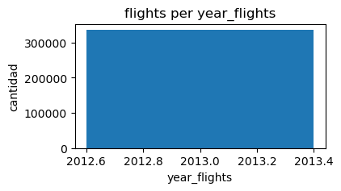

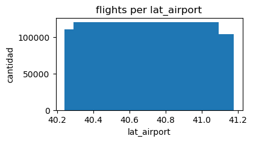

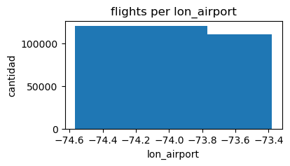

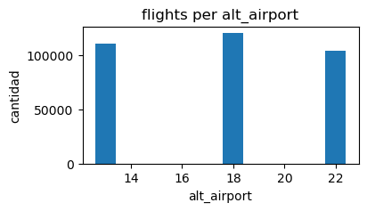

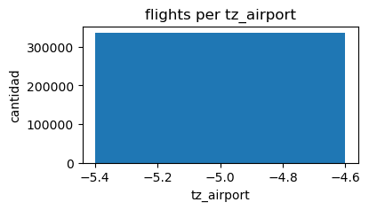

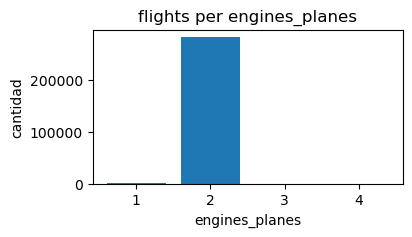

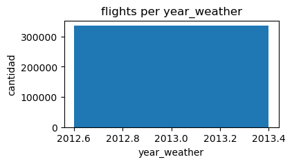

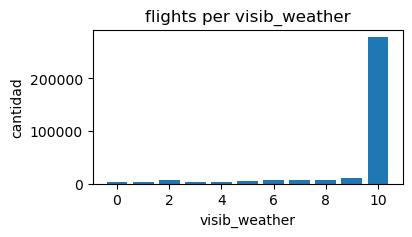

```python
for columnas in discretas:
    flights_count=cubo[columnas].value_counts()
    x=list(flights_count.index)
    plt.figure(figsize=(4,2))
    plt.bar(x,flights_count)
    plt.title("flights per " + columnas)
    plt.xlabel(columnas)
    plt.ylabel("cantidad")
    print("----")
    plt.show()
```

##### *Categoricas*

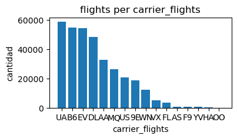

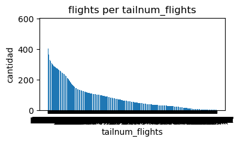

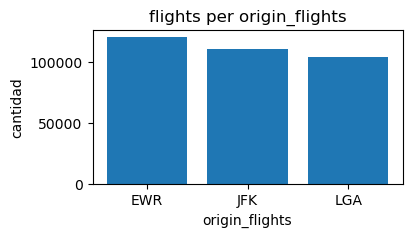

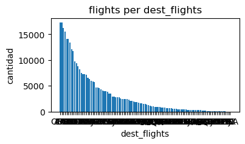

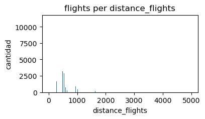

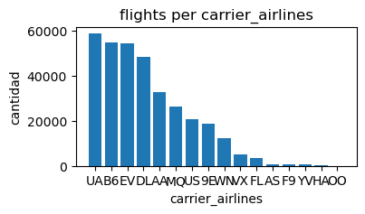

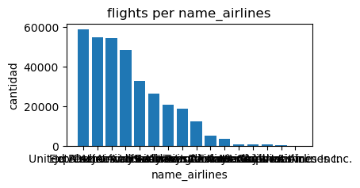

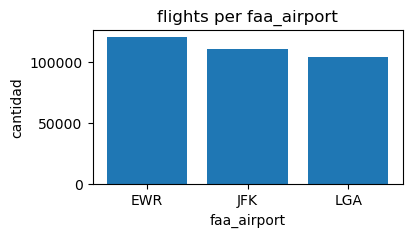

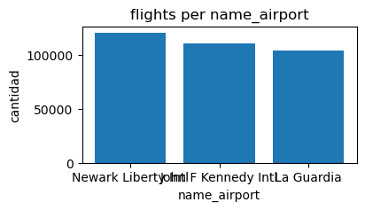

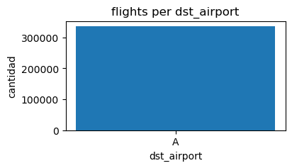

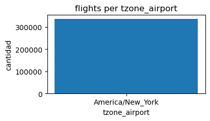

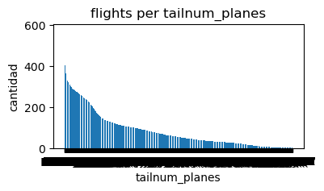

[6 more figures not shown]

```python
for columnas in categoricas:
    flights_count=cubo[columnas].value_counts()
    x=list(flights_count.index)
    plt.figure(figsize=(4,2))
    plt.bar(x,flights_count)
    plt.title("flights per " + columnas)
    plt.xlabel(columnas)
    plt.ylabel("cantidad")
    print("----")
    plt.show()
```

##### *Continuas*

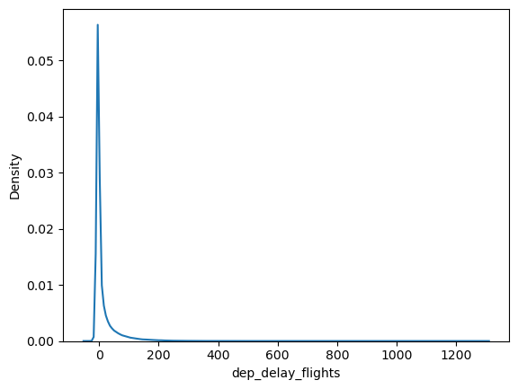

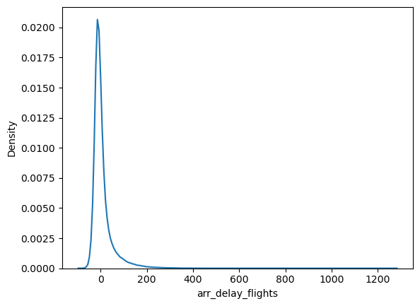

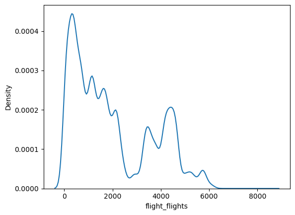

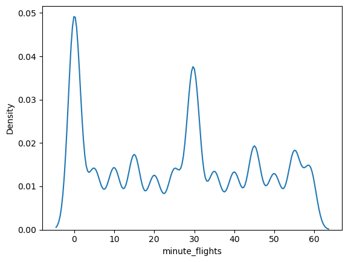

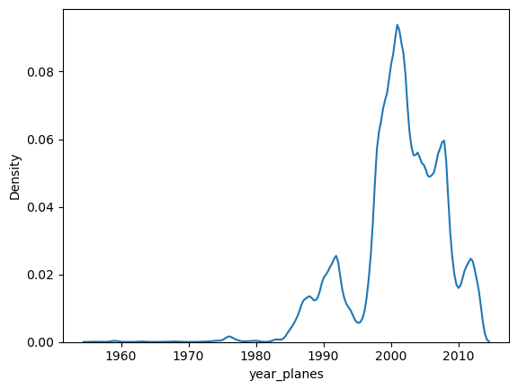

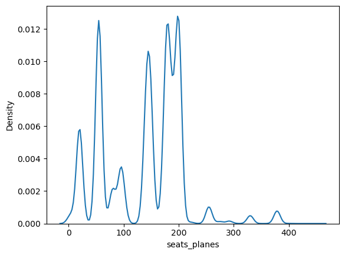

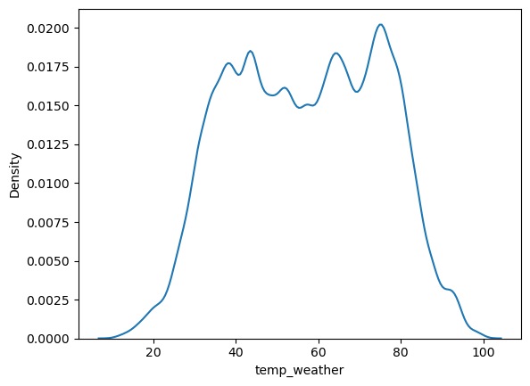

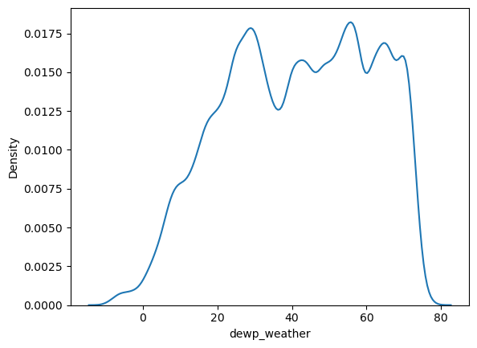

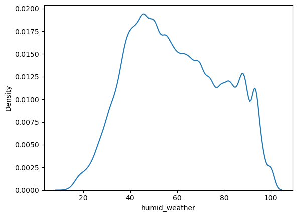

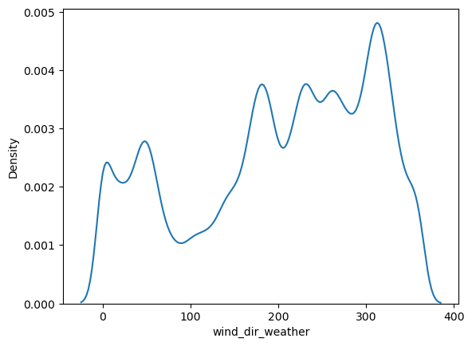

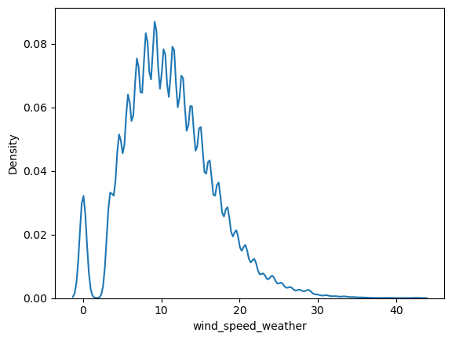

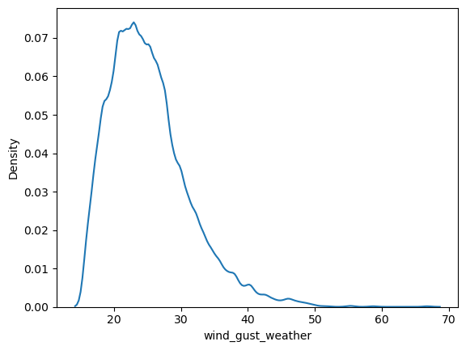

[2 more figures not shown]

```python
for columnas in continuas:
    sns.kdeplot(data=cubo[columnas])
    print("----")
    plt.show()
```

##### *Fecha y hora*

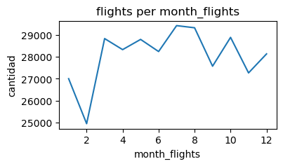

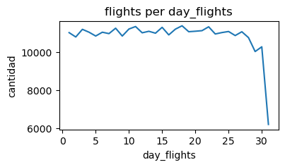

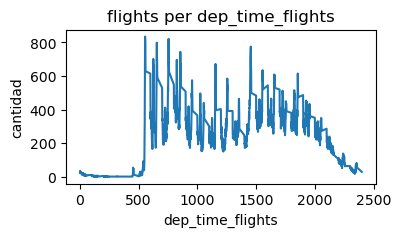

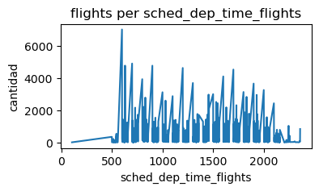

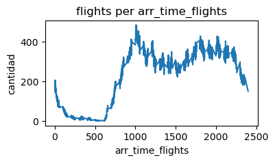

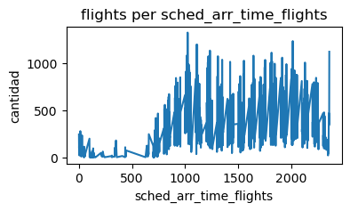

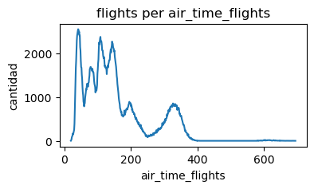

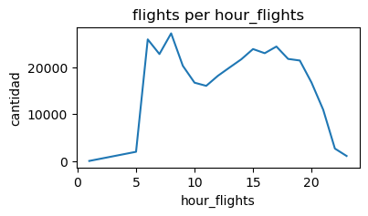

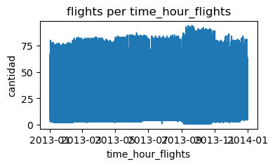

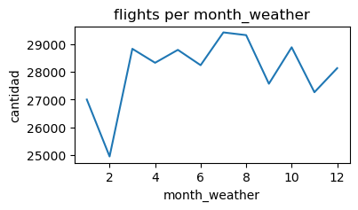

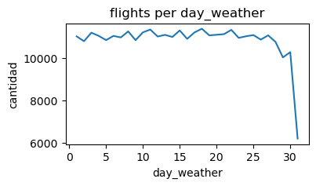

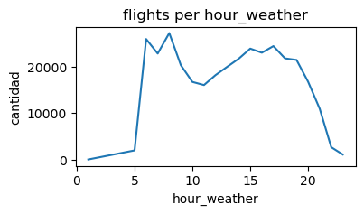

[2 more figures not shown]

```python
for columnas in datetime:
    flights_count=cubo[columnas].value_counts().sort_index()
    x=list(flights_count.index)
    plt.figure(figsize=(4,2))
    plt.plot(x,flights_count)
    plt.title("flights per " + columnas)
    plt.xlabel(columnas)
    plt.ylabel("cantidad")
    print("----")
    plt.show()
```

# **Carga de Proyecto a GitHub**

```python
%%cmd
git add .
```

```
Microsoft Windows [Versi�n 10.0.22631.3447]
(c) Microsoft Corporation. Todos los derechos reservados.

(base) C:\Users\HP\Documents\MBI\Ciencia de Datos Python\Proyecto-Final-CDP-flights>git add .
```

```
warning: in the working copy of '.ipynb_checkpoints/ProyectoFinal-checkpoint.ipynb', LF will be replaced by CRLF the next time Git touches it
warning: in the working copy of 'ProyectoFinal.ipynb', LF will be replaced by CRLF the next time Git touches it
```

```
(base) C:\Users\HP\Documents\MBI\Ciencia de Datos Python\Proyecto-Final-CDP-flights>
```

```python
%%cmd
git commit -m "carga de proyecto final CDPfinal"
```

```
Microsoft Windows [Versi�n 10.0.22631.3447]
(c) Microsoft Corporation. Todos los derechos reservados.

(base) C:\Users\HP\Documents\MBI\Ciencia de Datos Python\Proyecto-Final-CDP-flights>git commit -m "carga de proyecto final CDPfinal"
[master 92f8240] carga de proyecto final CDPfinal
 5 files changed, 127 insertions(+), 68 deletions(-)
 create mode 100644 CreacionTablasFlightsProyectoFinal.sql
 delete mode 100644 scripts sql.docx
 delete mode 100644 ~$ripts sql.docx

(base) C:\Users\HP\Documents\MBI\Ciencia de Datos Python\Proyecto-Final-CDP-flights>
```

```python
%%cmd
git status
```

```
Microsoft Windows [Versi�n 10.0.22631.3447]
(c) Microsoft Corporation. Todos los derechos reservados.

(base) C:\Users\HP\Documents\MBI\Ciencia de Datos Python\Proyecto-Final-CDP-flights>git status
On branch master
nothing to commit, working tree clean

(base) C:\Users\HP\Documents\MBI\Ciencia de Datos Python\Proyecto-Final-CDP-flights>
```

```python
%%cmd
git push origin master
```

```
Microsoft Windows [Versi�n 10.0.22631.3447]
(c) Microsoft Corporation. Todos los derechos reservados.

(base) C:\Users\HP\Documents\MBI\Ciencia de Datos Python\Proyecto-Final-CDP-flights>git push origin master
```

```
To https://github.com/djre0412/Proyecto-Final-CDP.git
   6f58f48..92f8240  master -> master
```

```
(base) C:\Users\HP\Documents\MBI\Ciencia de Datos Python\Proyecto-Final-CDP-flights>
```